# Trabalho Pratico dashboard

[figure not shown]

[figure not shown]

[figure not shown]

[figure not shown]

# Início

### Apresentação

Este dashboard é o **resumo executivo** do trabalho completo de análise dos dados do Spotify no Brasil. Ele reúne os gráficos mais representativos do relatório — selecionados por sua capacidade de comunicar, com o mínimo de esforço de leitura, os principais achados da análise (princípio central de *Storytelling com Dados*, de Cole Nussbaumer Knaflic).

Os indicadores foram construídos para avaliar:

- Evolução do conteúdo explícito;
- Sazonalidade das reproduções;
- Características das músicas mais populares;
- Impacto da pandemia na permanência dos artistas no ranking.

# Evolução do Conteúdo Explícito

### Gráfico

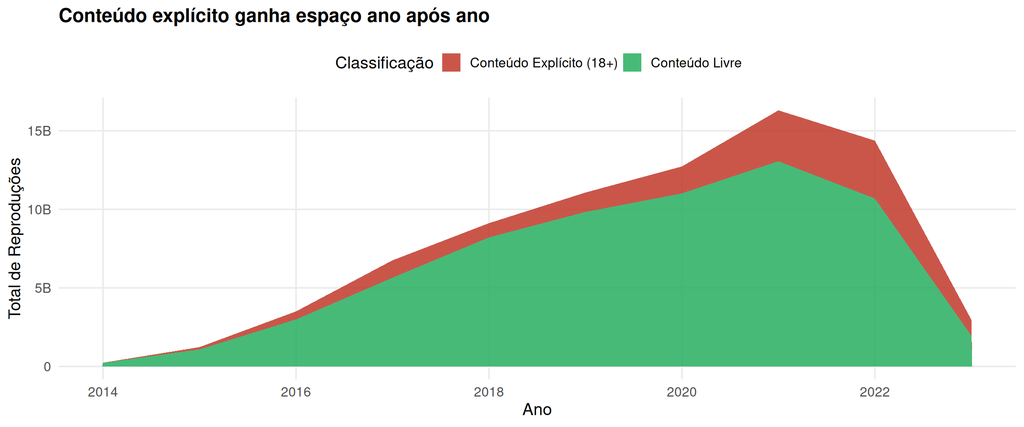

### Relatório

O gráfico evidencia a evolução do consumo de músicas explícitas e livres ao longo dos anos.

Observa-se uma participação crescente das músicas classificadas como explícitas, refletindo mudanças no perfil de consumo dos usuários brasileiros e na produção musical contemporânea. As cores vermelho e verde foram usadas de forma intencional para que o olhar do leitor vá direto à comparação entre os dois tipos de conteúdo.

# Sazonalidade dos Streams

### Gráfico

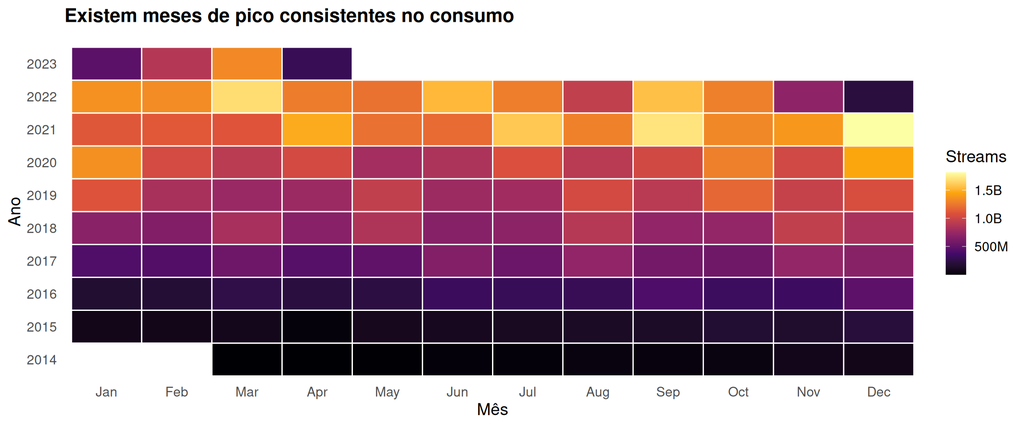

### Relatório

O mapa de calor permite visualizar os períodos de maior audiência durante cada ano.

Os tons mais claros/quentes indicam maior concentração de reproduções, revelando possíveis padrões sazonais relacionados a férias, festividades e lançamentos de novos sucessos. A paleta contínua “inferno” foi escolhida por ser perceptualmente uniforme, evitando o efeito enganoso de paletas arco-íris.

# Top 10 Músicas Mais Tocadas

### Gráfico

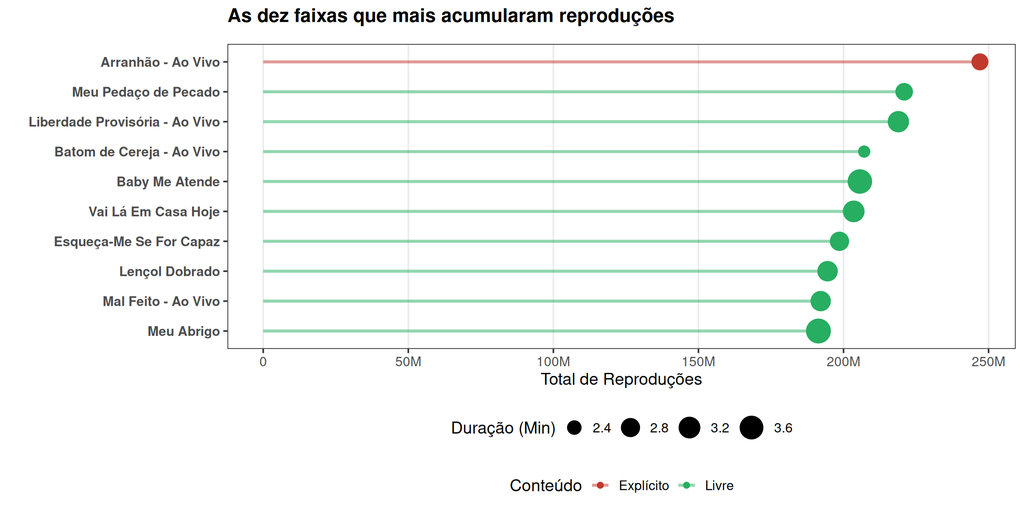

### Relatório

O gráfico apresenta as dez músicas com maior volume acumulado de reproduções, utilizando um gráfico de pirulito (lollipop) em vez de barras tradicionais para reduzir a quantidade de tinta na tela.

O tamanho dos pontos representa a duração média das músicas, enquanto as cores distinguem conteúdos explícitos e livres.

# Impacto da Pandemia

### Grafico

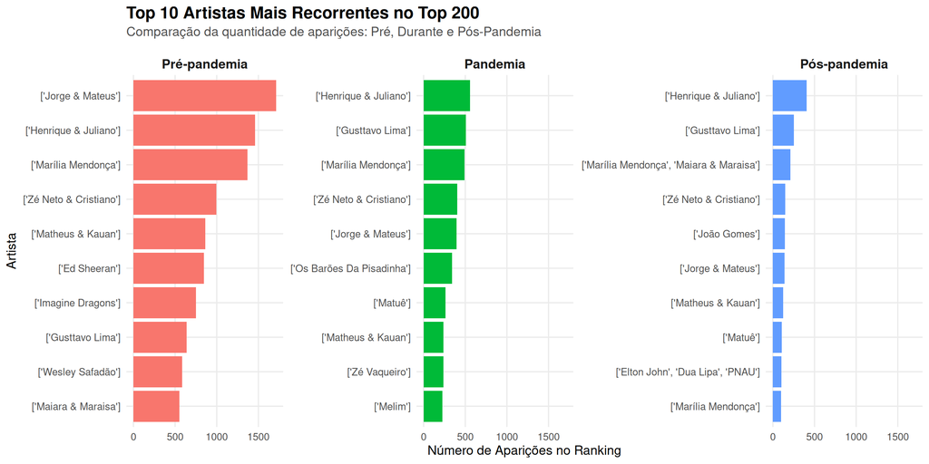

### Relatório

Este gráfico foi selecionado para o resumo por sintetizar a dominância de artistas em três fases históricas — o coração da pergunta de pesquisa deste trabalho.

A formatação foi ajustada para que os números no eixo inferior e os nomes dos artistas fiquem organizados e não se sobreponham, enquanto o título foi dimensionado para não ser cortado na tela. Podemos observar quais artistas se mantiveram no topo e quais são as novas tendências do mercado pós-pandemia.